# Mouse

```r
# 最终得到的target，有一个id对应多个MGI id
# gtf里的MGI id有重复值
gtf.Duplicated.MGI <- as.vector(na.omit(gtf$MGI[duplicated(gtf$MGI)]))
map.unique <- targets.gene.unique[!targets.gene.unique$MGI.id %in% gtf.Duplicated.MGI,]
map.duplicates <- targets.gene.unique[targets.gene.unique$MGI.id %in% gtf.Duplicated.MGI,]
gtf[gtf$MGI == "2442042" & !is.na(gtf$MGI),] # 1个MGI id对应两个Ensembl ID
```

```
##                   Ensembl Symbol     MGI      Gene.Type EntrezID          Name
## 914676 ENSMUSG00000053687  Dpep2 2442042 protein_coding   319446 dipeptidase 2
## 914739 ENSMUSG00000115067  Dpep2 2442042 protein_coding   319446 dipeptidase 2
##                Alias UniProt Chrosome     Start       End Length Strand
## 914676 F630103D06Rik  Q8C255     chr8 106711576 106718391   6816      -
## 914739 F630103D06Rik  Q8C255     chr8 106711577 106723055  11479      -
```

```r
targets.gene.unique[targets.gene.unique$MGI.id == "2442042",]
```

```
## # A tibble: 1 × 7
##   Type   Family.name               Target.id MGI.id MGI.symbol Mouse.Entrez.Gene
##   <chr>  <chr>                         <int> <chr>  <chr>      <chr>
## 1 enzyme Leukotriene and lipoxin …      1394 24420… Dpep2      319446
## # ℹ 1 more variable: Mouse.Ensembl.Gene <chr>
```

```r
targets.gene.unique$MGI.symbol <- gtf$Symbol[match(targets.gene.unique$MGI.id, gtf$MGI)]
targets.gene.unique$Mouse.Entrez.Gene <- gtf$EntrezID[match(targets.gene.unique$MGI.id, gtf$MGI)]
targets.gene.unique$Mouse.Ensembl.Gene <- gtf$Ensembl[match(targets.gene.unique$MGI.id, gtf$MGI)]
new.line <- targets.gene.unique[targets.gene.unique$MGI.id == "2442042",]
new.line$Mouse.Ensembl.Gene <- "ENSMUSG00000115067"
targets.gene.unique <- rbind(targets.gene.unique, new.line)


table(duplicated(targets.gene.unique$Mouse.Ensembl.Gene)) # 均无重复值
```

```
##
## FALSE
##  2849
```

```r
table(duplicated(targets.gene.unique$MGI.id)) # 有一个重复值
```

```
##
## FALSE  TRUE
##  2848     1
```

```r
targets.gene.unique <- targets.gene.unique[,c("Mouse.Ensembl.Gene", "MGI.id", "MGI.symbol", "Mouse.Entrez.Gene", "Target.id","Type", "Family.name")]
colnames(targets.gene.unique) <- c("Ensembl","MGI", "Symbol", "Entrez", "Target.ID","Type", "Family")

Mouse_GuideToPHARMACOLOGY_Targets <- targets.gene.unique
usethis::use_data(Mouse_GuideToPHARMACOLOGY_Targets, overwrite = TRUE)
```

```
## ✔ Saving 'Mouse_GuideToPHARMACOLOGY_Targets' to 'data/Mouse_GuideToPHARMACOLOGY_Targets.rda'
## • Document your data (see 'https://r-pkgs.org/data.html')
```

```r
# saveRDS(targets.gene.unique,file = "../data/Mouse_GuideToPHARMACOLOGY_Targets.rds")
```

```r
janitor::get_dupes(targets.gene.unique, Target.ID)
```

```
## # A tibble: 9 × 8
##   Target.ID dupe_count Ensembl            MGI     Symbol  Entrez Type     Family
##       <int>      <int> <chr>              <chr>   <chr>   <chr>  <chr>    <chr>
## 1       803          3 ENSMUSG00000006057 107653  Atp5mc1 11951  transpo… F-typ…
## 2       803          3 ENSMUSG00000062683 1915192 Atp5mc2 67942  transpo… F-typ…
## 3       803          3 ENSMUSG00000018770 2442035 Atp5mc3 228033 transpo… F-typ…
## 4        34          2 ENSMUSG00000049115 87964   Agtr1a  11607  gpcr     Angio…
## 5        34          2 ENSMUSG00000054988 87965   Agtr1b  11608  gpcr     Angio…
## 6      1394          2 ENSMUSG00000053687 2442042 Dpep2   319446 enzyme   Leuko…
## 7      1394          2 ENSMUSG00000115067 2442042 Dpep2   319446 enzyme   Leuko…
## 8      2997          2 ENSMUSG00000028076 107674  Cd1d1   12479  other_p… CD mo…
## 9      2997          2 ENSMUSG00000041750 107675  Cd1d2   12480  other_p… CD mo…
```

```r
# 1. 同一Target ID对应多个不同的同系物
# 2. 同一Target ID对应多个不同的Eesembl ID，有相同的MGI ID和Symbol，基因组多拷贝？还是遗留的注释信息？
```

**ligand文件 中有哪些 ligand**

ligand.ID.mapping 与 ligand 两个文档内容是一致的； 注意：一个ligand ID可以对应多个基因; 一个基因ID也可以对应多个Ligand ID。

```r
ligand <- read.csv("../inst/extdata/GuideToPharmacology/ligands.csv.gz", stringsAsFactors = FALSE, skip = 1)
ligand.ID.mapping <- read.csv("../inst/extdata/GuideToPharmacology/ligand_id_mapping.csv.gz", stringsAsFactors = FALSE, skip = 1)

all(ligand.ID.mapping$Ensembl.ID == ligand$Ensembl.ID)
```

```
## [1] TRUE
```

```r
# ligand.ID.mapping 与ligand 里的Ensembl.ID是一样的，并且维度也一样。

# 提取所有人里的Ligands基因。
table(ligand.ID.mapping$Type)
```

```
##
##          Antibody         Inorganic        Metabolite   Natural product
##               333                39               517               336
##           Peptide Synthetic organic
##              2255              7868
```

```r
table(duplicated(ligand.ID.mapping$Ligand.id)) # Liand id是没有重复值的！
```

```
##
## FALSE
## 11348
```

```r
ligands.id.uniqe <- ligand.ID.mapping[grepl("ENSMUSG", ligand.ID.mapping$Ensembl.ID),c("Ligand.id","Name", "Species" ,"Type","Ensembl.ID")]
table(ligands.id.uniqe$Type)
```

```
##
## Peptide
##     138
```

```r
# 一个Ligand id 对应多个Ensembl id，并且去除非人基因
tmp <- c()
for (i in ligands.id.uniqe$Ensembl.ID) {
  if(grepl("|", i,fixed = TRUE)){
    tmp <- append(tmp, paste0(grep("^ENSMUSG",unlist(strsplit(i,split = "|",fixed = TRUE)),value = TRUE),collapse = ";"))
  }else{
    tmp <- append(tmp, i)
  }
}
ligands.id.uniqe$Ensembl.ID <- tmp

# 修正Ensembl IDs
## 制备old - new name数据库
ensembl.ids.unique <- unique(unlist(lapply(ligands.id.uniqe$Ensembl.ID, function(x)unlist(strsplit(x, split = ";",fixed = TRUE))))) # 提取所有IDs
ensembl.ids.unique.lost <- ensembl.ids.unique[!ensembl.ids.unique %in% gtf$Ensembl] # 提取不能被识别的
ligands.id.uniqe[ligands.id.uniqe$Ensembl.ID %in% ensembl.ids.unique.lost,]
```

```
##      Ligand.id                             Name           Species    Type
## 3319       912 corticotrophin-releasing hormone Human, Mouse, Rat Peptide
##             Ensembl.ID
## 3319 ENSMUSG0000004979
```

```r
ligands.id.uniqe[grepl("ENSMUSG00000055951", ligands.id.uniqe$Ensembl.ID),]
```

```
##      Ligand.id  Name Species    Type                            Ensembl.ID
## 2052      4422 CCL25   Mouse Peptide ENSMUSG00000023235;ENSMUSG00000055951
```

```r
# corticotrophin-releasing hormone Human对应的 ENSMUSG0000004979 应该改为ENSMUSG00000049796
# CCL25 对应两个ENSMUSG00000023235;ENSMUSG00000055951，去除ENSMUSG00000055951就可以了。
ligands.id.uniqe$Ensembl.ID[grepl("ENSMUSG00000055951", ligands.id.uniqe$Ensembl.ID)] <- "ENSMUSG00000023235"
ligands.id.uniqe$Ensembl.ID[ligands.id.uniqe$Ensembl.ID %in% ensembl.ids.unique.lost] <- "ENSMUSG00000049796"

# 依据Esembl ID拆分和整理数据
janitor::get_dupes(ligands.id.uniqe, Ensembl.ID) # 发现有重复的Ensembl IDs，一个Ensembl ID对应多个ligand ID
```

```
##            Ensembl.ID dupe_count Ligand.id                                 Name
## 1  ENSMUSG00000000394          6      1136                             glucagon
## 2  ENSMUSG00000000394          6      5194              glucagon-like peptide 1
## 3  ENSMUSG00000000394          6      1132 glucagon-like peptide 1-(7-36) amide
## 4  ENSMUSG00000000394          6      3544       glucagon-like peptide 1-(7-37)
## 5  ENSMUSG00000000394          6      3540              glucagon-like peptide 2
## 6  ENSMUSG00000000394          6      3541       glucagon-like peptide 2-(3-33)
## 7  ENSMUSG00000020660          5      1331                                 ACTH
## 8  ENSMUSG00000020660          5      1320                          &alpha;-MSH
## 9  ENSMUSG00000020660          5      3722                     &beta;-endorphin
## 10 ENSMUSG00000020660          5      3607                           &beta;-MSH
## 11 ENSMUSG00000020660          5      1333                          &gamma;-MSH
## 12 ENSMUSG00000037010          4       605                            apelin-13
## 13 ENSMUSG00000037010          4      3556                            apelin-17
## 14 ENSMUSG00000037010          4      3555                            apelin-36
```

[output cut: 95 more lines]

```r
# 按照Ensembl ID，将相同ligand ID的条目合并
ligands.id.uniqe %>%
  dplyr::group_by(Ensembl.ID) %>%
  mutate(Ligand.id = paste0(Ligand.id, collapse = ";"), # 合并id列
          Name = paste0(Name, collapse = ";"))  %>% # 合并name列
  filter(row_number()==1) %>%  # 仅保留第一行
  ungroup() -> ligands.gene.uniqe
table(ligands.gene.uniqe$Ensembl.ID %in% gtf$Ensembl)
```

```
##
## TRUE
##  104
```

```r
ligands.gene.uniqe$Symbol <- gtf$Symbol[match(ligands.gene.uniqe$Ensembl.ID, gtf$Ensembl)]
ligands.gene.uniqe <- ligands.gene.uniqe[,c("Ensembl.ID", "Symbol","Ligand.id", "Name", "Type" )]
dim(ligands.gene.uniqe)
```

```
## [1] 104   5
```

```r
table(ligands.gene.uniqe$Type)
```

```
##
## Peptide
##     104
```

```r
ligands.gene.uniqe$Name <- NULL
colnames(ligands.gene.uniqe) <- c("Ensembl","Symbol", "Ligand.ID","Type")

Mouse_GuideToPHARMACOLOGY_LigandsPeptides <- ligands.gene.uniqe
usethis::use_data(Mouse_GuideToPHARMACOLOGY_LigandsPeptides, overwrite = TRUE)
```

```
## ✔ Saving 'Mouse_GuideToPHARMACOLOGY_LigandsPeptides' to 'data/Mouse_GuideToPHARMACOLOGY_LigandsPeptides.rda'
## • Document your data (see 'https://r-pkgs.org/data.html')
```

```r
# saveRDS(ligands.gene.uniqe, file = "../data/Mouse_GuideToPHARMACOLOGY_LigandsPeptides.rds")
```

**detailed.endogenous.ligand** 注意有些行的ligand ID是空的

发现这里的endogenous ligand与前面的peptides ligand是一样的，这里不再重复输出。

```r
# detailed.endogenous.ligand <-  read.csv("../inst/extdata/GuideToPharmacology/detailed_endogenous_ligands.csv.gz", stringsAsFactors = FALSE, skip = 1)
# head(detailed.endogenous.ligand)
# detailed.endogenous.ligand[!detailed.endogenous.ligand$Ligand.ID %in% ligand$Ligand.ID,]
# detailed.endogenous.ligand.Mouse <- detailed.endogenous.ligand[detailed.endogenous.ligand$Interaction.Species == "Mouse",]
# # 提取所有唯一的ENSMUSG ID
# uniqe.ensembl.ids <- unique(trimws(unlist(lapply(grep("ENSMUSG",detailed.endogenous.ligand.Mouse$Ligand.Ensembl.Gene.ID,fixed = TRUE,value = TRUE),function(x)unlist(strsplit(x,split = "|",fixed = TRUE))))))
# length(uniqe.ensembl.ids) # 粗略估计这里的peptide ligand数目
# table(uniqe.ensembl.ids %in% ligands.gene.uniqe$Ensembl)
# table(uniqe.ensembl.ids %in% db.ligands.ensembl$old)
# all(detailed.endogenous.ligand.Mouse$Ligand.ID %in% all.ligands.and.targets.interactions$Ligand.ID) # 也都被包括到interactions中
```

**condensed.endogenous.ligand** 文档targets基本都是人的基因。

```r
# condensed.endogenous.ligand <- read.csv("../inst/extdata/GuideToPharmacology/detailed_endogenous_ligands.csv.gz", stringsAsFactors = FALSE, skip = 1)
# condensed.endogenous.ligand <- condensed.endogenous.ligand
# condensed.endogenous.ligand[!condensed.endogenous.ligand$Ligand.ID %in% ligands.id.uniqe$Ligand.ID,]
# # 一个Ligand id 对应多个Ensembl id，并且去除非人基因
# tmp <- c()
# for (i in condensed.endogenous.ligand$Ligand.Ensembl.Gene.ID) {
#   if(grepl("|", i,fixed = TRUE)){
#     tmp <- append(tmp, paste0(grep("^ENSMUSG",unlist(strsplit(i,split = "|",fixed = TRUE)),value = TRUE),collapse = ";"))
#   }else{
#     tmp <- append(tmp, i)
#   }
# }
# condensed.endogenous.ligand$Ligand.Ensembl.Gene.ID <- tmp
# tmp <- c()
# for (i in condensed.endogenous.ligand$Target.Ensembl.Gene.ID) {
#   if(grepl("|", i,fixed = TRUE)){
#     tmp <- append(tmp, paste0(grep("^ENSMUSG",unlist(strsplit(i,split = "|",fixed = TRUE)),value = TRUE),collapse = ";"))
#   }else{
#     tmp <- append(tmp, i)
#   }
# }
# condensed.endogenous.ligand$Target.Ensembl.Gene.ID <- tmp
# condensed.endogenous.ligand$Ligand.Symbol <- update_IDs(old = condensed.endogenous.ligand$Ligand.Ensembl.Gene.ID, db = gtf, from = "Ensembl", to = "Symbol", fixed = TRUE, split = ";")
# condensed.endogenous.ligand$Target.Symbol <- update_IDs(old = condensed.endogenous.ligand$Target.Ensembl.Gene.ID, db = gtf, from = "Ensembl", to = "Symbol", fixed = TRUE, split = ";")
# head(sort(table(condensed.endogenous.ligand$Ligand.Symbol),decreasing = TRUE),30)
# head(sort(table(condensed.endogenous.ligand$Target.Symbol),decreasing = TRUE),30)
#
# # 不是所有的ligand基因都记录了targets
# table(ligands.id.uniqe$Ligand.id %in% condensed.endogenous.ligand$Ligand.ID)
```

**all.ligands.and.targets.interactions**

target_ligand：注意，这个表示这个target本来也是一个ligand，但是在这个条目中，他是一个target。

```r
all.ligands.and.targets.interactions <- read.csv("../inst/extdata/GuideToPharmacology/interactions.csv.gz", stringsAsFactors = FALSE, skip = 1)
complete.peptide.ligand <-  read.csv("../inst/extdata/GuideToPharmacology/peptides.csv.gz", stringsAsFactors = FALSE, skip = 1)
# 只保留鼠的
all.interactions.targets <- all.ligands.and.targets.interactions[all.ligands.and.targets.interactions$Target.Species == "Mouse",]
# 配体与配体的互作？这里不再进行深入探索，以后再说吧！  Target.Ligand 开头的列是啥？
target.id.NA <- dplyr::distinct(all.interactions.targets[is.na(all.interactions.targets$Target.ID),c("Target.ID", "Target.Ligand.ID","Target.Ligand.Ensembl.Gene.ID","Ligand.ID")]) # 注意target id为NA的行被删除
target.id.NA #这是啥？？？
```

```
##   Target.ID Target.Ligand.ID Target.Ligand.Ensembl.Gene.ID Ligand.ID
## 1        NA             5880                                    9685
```

```r
table(targets.gene.unique$Ensembl %in% unique(target.id.NA$Target.Ligand.Ensembl.Gene.ID))
```

```
##
## FALSE
##  2849
```

```r
table(ligands.id.uniqe$Ligand.id %in% unique(target.id.NA$Target.Ligand.ID))
```

```
##
## FALSE
##   138
```

```r
table(unique(target.id.NA$Target.Ligand.ID) %in% ligands.id.uniqe$Ligand.id)
```

```
##
## FALSE
##     1
```

```r
# 注意这些ligand并未被记录为target！
all.interactions.targets  <-  all.interactions.targets[!is.na(all.interactions.targets$Target.ID),]
table(complete.peptide.ligand$Ligand.id %in% ligands.id.uniqe$Ligand.id)
```

```
##
## FALSE  TRUE
##  2117   138
```

```r
table(all.interactions.targets$Ligand.ID %in% ligands.id.uniqe$Ligand.id) # 比complete.peptide.ligand数据库记录ligands的要多！
```

```
##
## FALSE  TRUE
##  1095    47
```

比较targets数目，基于targets ids

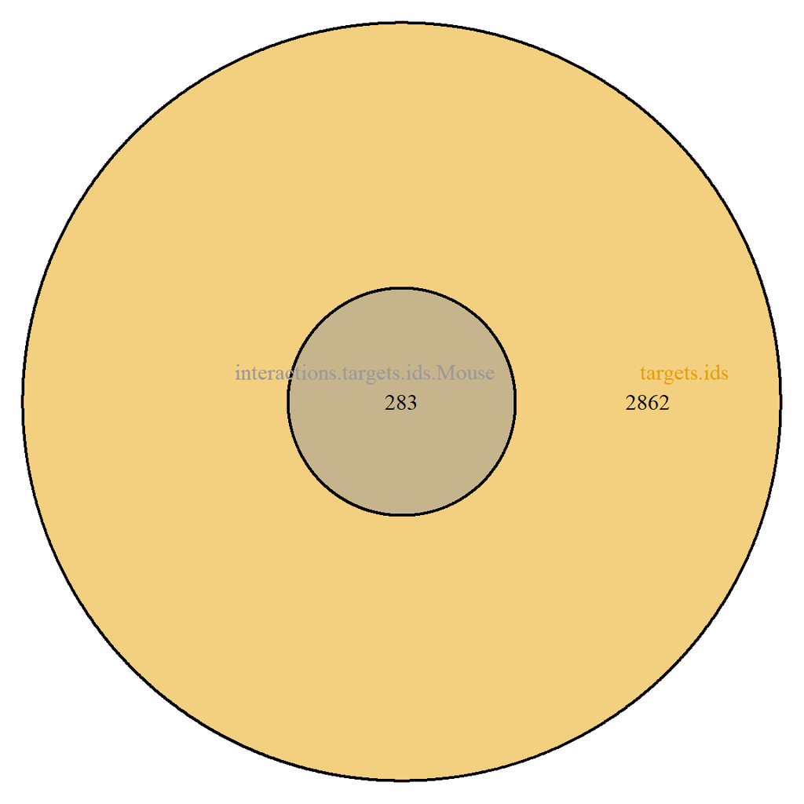

```r
# 发现interactions里的targets id 与 target.and.family里的targets id关系
display_venn(list(interactions.targets.ids.Mouse = na.omit(unique(all.interactions.targets$Target.ID)),
                  targets.ids = na.omit(unique(target.and.family$Target.id))),
             fill = c("#999999", "#E69F00"),cat.col = c("#999999", "#E69F00"), cat.default.pos = "text")
```